# A1.Financiacion del Gasto Sanitario

Alicia Perdices Guerra

12 de abril, 2021

#### **1.PROCESAMIENTO DE LOS DATOS.**

- En primer lugar leemos el fichero:

```r
gasto_f<-read.csv("C:/temp/GastoSanitario_Financiacion.csv",sep= ",")
```

- Realicemos una breve inspección de los datos

```r
str(gasto_f)
```

```
## 'data.frame':    2000 obs. of  6 variables:
##  $ TIME              : int  2009 2009 2009 2009 2009 2009 2009 2009 2009 2009 ...
##  $ GEO               : Factor w/ 40 levels "Austria","Belgium",..: 15 15 15 15 15 16 16 16 16 16 ...
##  $ UNIT              : Factor w/ 1 level "Million euro": 1 1 1 1 1 1 1 1 1 1 ...
##  $ ICHA11_HF         : Factor w/ 5 levels "All financing schemes",..: 1 4 3 2 5 1 4 3 2 5 ...
##  $ Value             : Factor w/ 1185 levels ":","0.00","1,001,514.67",..: 1 1 1 1 1 1 1 1 1 1 ...
##  $ Flag.and.Footnotes: Factor w/ 2 levels "","b": 1 1 1 1 1 1 1 1 1 1 ...
```

```r
colnames(gasto_f) #Nombre de las variables
```

```
## [1] "TIME"               "GEO"                "UNIT"
## [4] "ICHA11_HF"          "Value"              "Flag.and.Footnotes"
```

```r
nrow(gasto_f) #Número de registros
```

```
## [1] 2000
```

```r
ncol(gasto_f) #Número de variables
```

```
## [1] 6
```

*Observamos las siguientes variables:

- **TIME**: variable cuantitativa. Indica el año en el que se ha realizado la medida, en este caso el valor de la variable “Value”. Se ha cargado bien como número entero.
- **GEO**: variable cualitativa. Indica el país o región en el que se ha realizado la medida.Se ha cargado bien como factor.
- **UNIT**: variable cualitativa. Indica la medida de la variable valor.Se ha cargado bien como factor.
- **ICHA11_HF**: variable cualitativa. Indica el organismo que financia la sanidad, ya sea gubernamental o por seguros privados etc..
- **Value**: Variable cuantitativa. Indica el valor en Millones de Euros de esta financiación.Se ha cargado mal como factor. Haremos la transformación a valor numérico.
- **Fal.and.footnotes**. Notas sobre etiquetas. Eliminamos esta columna.

*Años de las mediciones:

```r
unique(gasto_f$TIME)
```

```
##  [1] 2009 2010 2011 2012 2013 2014 2015 2016 2017 2018
```

*Paises:

```r
unique(gasto_f$GEO)
```

```
##  [1] European Union - 27 countries (from 2020)
##  [2] European Union - 28 countries (2013-2020)
##  [3] European Union - 27 countries (2007-2013)
##  [4] European Union - 15 countries (1995-2004)
##  [5] Euro area - 19 countries  (from 2015)
##  [6] Euro area - 18 countries (2014)
##  [7] Euro area - 12 countries (2001-2006)
##  [8] Belgium
##  [9] Bulgaria
## [10] Czechia
## [11] Denmark
## [12] Germany (until 1990 former territory of the FRG)
## [13] Estonia
## [14] Ireland
## [15] Greece
```

[output cut: 26 more lines]

*Unidad de las mediciones:

```r
unique(gasto_f$UNIT)
```

```
## [1] Million euro
## Levels: Million euro
```

*Variable que indica cómo se financia el gasto sanitario

```r
unique(gasto_f$ICHA11_HF)
```

```
## [1] All financing schemes
## [2] Government schemes and compulsory contributory health care financing schemes
## [3] Government schemes
## [4] Compulsory contributory health insurance schemes and compulsory medical saving accounts (CMSA)
## [5] Social health insurance schemes
## 5 Levels: All financing schemes ...
```

- Eliminamos la columna Fal.and.footnotes.

```r
gasto_f<-gasto_f[,-6]
```

- Tendríamos que convertir la columna Value a numérico porque se ha cargado como factor y es erróneo. El resto de variables tienen el tipo correcto.

```r
gasto_f$Value<-as.character(gasto_f$Value)
gasto_f$Value<-(gsub(',','.',gasto_f$Value) )
gasto_f$Value<-substr(gasto_f$Value,1,nchar(gasto_f$Value)-3)
gasto_f$Value<-as.numeric(gasto_f$Value)
```

- Comprobamos que valores tenemos en la columna **Value**:

```r
table(gasto_f$Value, useNA = "ifany")
```

```
##
##       0   1.001   1.009   1.029    1.03   1.042   1.045   1.066   1.067   1.069
##      89       1       1       2       2       1       1       1       1       1
##    1.08   1.108   1.109   1.114    1.12   1.137   1.144   1.157   1.172   1.211
##       2       1       1       1       2       1       2       1       2       1
##   1.218   1.222   1.227   1.232   1.233   1.234    1.24   1.245   1.249   1.265
##       1       2       1       1       1       1       2       1       1       1
##   1.274   1.277   1.289    1.29   1.301   1.318   1.322    1.35   1.364   1.369
##       4       2       2       1       2       1       1       1       1       1
##   1.385   1.388   1.395   1.402    1.41   1.411   1.422    1.43   1.432   1.435
##       2       1       2       1       2       1       1       1       1       1
##   1.442   1.466   1.473   1.482   1.497   1.519   1.522    1.53   1.533   1.553
##       1       1       2       2       1       1       1       1       2       1
##   1.556   1.562   1.572   1.577   1.601   1.609    1.61   1.624   1.627    1.64
##       3       2       1       1       1       1       2       1       1       2
##   1.705   1.719   1.734   1.741   1.783   1.791   1.804   1.807    1.81   1.812
##       1       1       1       2       1       2       1       1       1       1
##   1.823   1.862     1.9    1.91   1.933   1.946   1.981   1.993   2.005   2.013
##       1       1       1       1       1       2       1       1       2       1
##   2.016   2.027   2.031   2.035   2.037    2.04   2.059   2.067   2.096   2.108
##       1       1       1       1       2       1       1       1       1       1
##   2.135   2.141   2.146   2.156   2.176    2.18   2.193   2.248   2.261   2.264
##       1       2       1       1       2       1       1       2       1       1
##   2.265   2.275   2.301   2.325   2.345   2.357   2.366   2.376   2.383   2.391
##       1       1       1       2       2       1       2       1       1       1
##   2.392   2.393   2.411   2.414   2.422   2.423   2.434   2.436   2.441   2.463
##       1       2       1       2       1       2       1       1       1       1
##   2.484   2.493     2.5   2.501   2.507   2.509   2.522   2.525    2.53   2.541
##       1       1       1       1       1       1       1       2       2       1
##    2.55    2.57   2.581   2.589   2.591   2.594   2.605   2.614   2.627   2.636
##       2       1       1       1       1       1       1       1       1       2
##   2.638   2.645   2.653   2.668   2.708   2.718   2.732   2.746   2.751   2.765
##       1       1       1       1       2       2       1       1       1       1
##   2.773   2.782   2.822   2.823   2.841    2.85   2.855   2.873   2.881   2.907
##       2       1       1       1       1       1       1       1       1       1
##   2.919   2.942   2.946   2.949   2.972   2.987       3   3.003   3.027    3.14
##       1       1       1       1       1       1       6       1       1       1
##   3.174   3.183   3.185   3.199   3.305   3.309   3.327   3.336   3.346   3.377
##       2       1       1       1       1       1       1       1       1       1
##   3.386   3.428   3.479   3.482    3.52   3.524   3.564   3.628   3.636   3.771
```

[output cut: 166 more lines]

```
##       2       1       1       3       1       2       1       2       2       1
##     700     704     711     719     720     723     735     739     744     750
##       1       2       1       2       1       1       2       2       1       2
##     767 767.126     770 780.126     795     801 801.739     802 810.939  812.47
##       1       1       2       1       3       1       1       2       1       1
##     814 825.216 834.776 836.403     854     860 863.789     869 873.898 875.617
##       2       1       1       1       2       1       1       2       1       1
##     883     889     892 892.236     898 902.645 904.452     907     910     916
##       2       1       2       1       1       1       1       2       1       2
## 919.005 920.675     922     925     928 931.919     932 933.912     936     937
##       1       1       2       1       1       1       1       1       1       2
##     939     945 946.258     965     967     970     974     977 986.082 989.009
##       1       1       1       1       1       3       2       2       1       1
##     991     997     999    <NA>
##       1       1       1     568
```

- Observamos que tenemos **568 valores perdidos**.Guardamos en la variable **idx** los índices de los registros con valores **NA** de la variable **Value**.

```r
idx<-which(is.na(gasto_f$Value))
length(idx)
```

```
## [1] 568
```

- Grafiquemos la información que contiene la variable **Value**

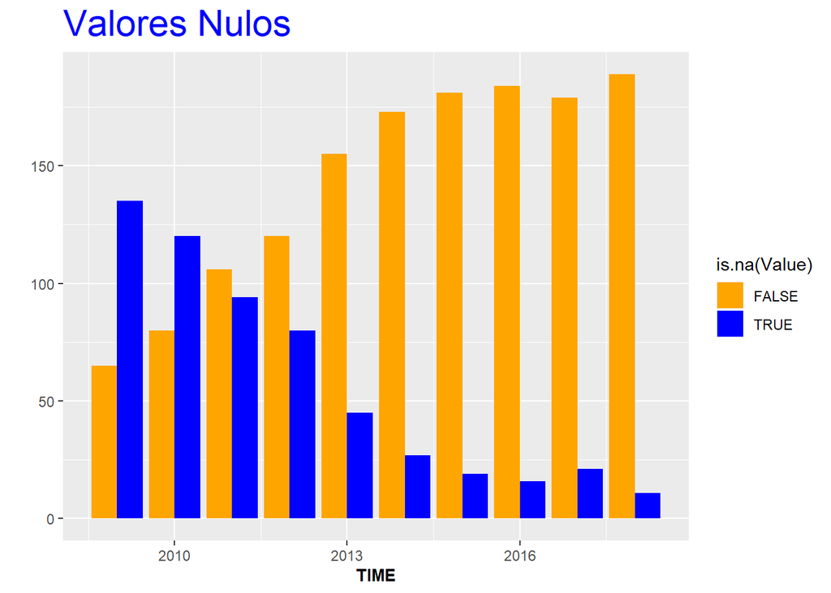

```r
library(ggplot2)
library(scales)
g = ggplot(gasto_f, aes(TIME, fill=is.na(Value)) ) +
labs(title = "Valores Nulos")+ylab("") +
theme(plot.title = element_text(size = rel(2), colour = "blue"))

g+geom_bar(position="dodge") + scale_fill_manual(values = alpha(c("orange", "blue"), 1)) +
theme(axis.title.x = element_text(face="bold", size=10))
```

- En caso de detectar algún valor anómalo (en nuestro caso los NAS) en las variables tendríamos que realizar una imputación de esos valores o bien sustituyéndolos por la media o usando el algoritmo KNN ( k-Nearest Neighbour) con los 3 vecinos más cercanos usando la distancia que consideremos, en este caso usaremos Gower(Mediana), por ser una medida más robusa frente a extremos.

```r
library(VIM)
output<-kNN(gasto_f, variable=c("Value"),k=3)
gasto_f<-output
```

- Comprobamos que no tenemos valores nulos después de la imputación

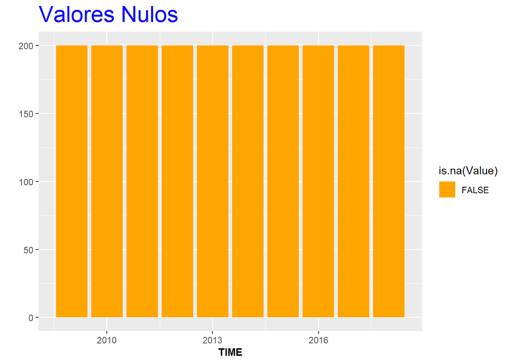

```r
g = ggplot(gasto_f, aes(TIME, fill=is.na(Value)) ) +
labs(title = "Valores Nulos")+ylab("") +
theme(plot.title = element_text(size = rel(2), colour = "blue"))

g+geom_bar(position="dodge") + scale_fill_manual(values = alpha(c("orange", "blue"), 1)) +
theme(axis.title.x = element_text(face="bold", size=10))
```

- Con el siguiente gráfico, observaremos que la variable **Value** tiene outliers o valores extremos

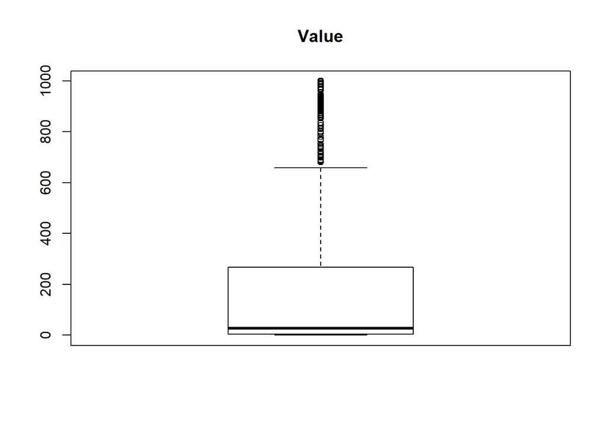

```r
boxplot(gasto_f$Value, main="Value")
```

- Por otro lado, revisamos para el resto de columnas si tenemos valores NA.(desconocidos o perdidos)

```r
table(gasto_f$TIME, useNA = "ifany")
```

```
##
## 2009 2010 2011 2012 2013 2014 2015 2016 2017 2018
##  200  200  200  200  200  200  200  200  200  200
```

```r
table(gasto_f$GEO, useNA = "ifany")
```

```
##
##                                          Austria
##                                               50
##                                          Belgium
##                                               50
##                           Bosnia and Herzegovina
##                                               50
##                                         Bulgaria
##                                               50
##                                          Croatia
##                                               50
##                                           Cyprus
##                                               50
##                                          Czechia
##                                               50
##                                          Denmark
##                                               50
##                                          Estonia
##                                               50
##             Euro area - 12 countries (2001-2006)
##                                               50
##                  Euro area - 18 countries (2014)
##                                               50
##            Euro area - 19 countries  (from 2015)
##                                               50
##        European Union - 15 countries (1995-2004)
##                                               50
##        European Union - 27 countries (2007-2013)
##                                               50
##        European Union - 27 countries (from 2020)
##                                               50
##        European Union - 28 countries (2013-2020)
##                                               50
##                                          Finland
##                                               50
##                                           France
##                                               50
## Germany (until 1990 former territory of the FRG)
##                                               50
##                                           Greece
```

[output cut: 26 more lines]

```
##                                               50
##                                          Romania
##                                               50
##                                         Slovakia
##                                               50
##                                         Slovenia
##                                               50
##                                            Spain
##                                               50
##                                           Sweden
##                                               50
##                                      Switzerland
##                                               50
##                                   United Kingdom
##                                               50
```

```r
table(gasto_f$UNIT, useNA = "ifany")
```

```
##
## Million euro
##         2000
```

```r
table(gasto_f$ICHA11_HF, useNA = "ifany")
```

```
##
##                                                                          All financing schemes
##                                                                                            400
## Compulsory contributory health insurance schemes and compulsory medical saving accounts (CMSA)
##                                                                                            400
##                                                                             Government schemes
##                                                                                            400
##                   Government schemes and compulsory contributory health care financing schemes
##                                                                                            400
##                                                                Social health insurance schemes
##                                                                                            400
```

Observamos que no existen ahora valores perdidos después de la imputación.La suma de las cantidades de cada variable, suman el total.

- Finalmente, creamos un fichero con toda la información corregida.

```r
write.csv(gasto_f, file="GastoSanitario_Financiacion_clean.csv", row.names = FALSE)
```